# WT ANALYSIS

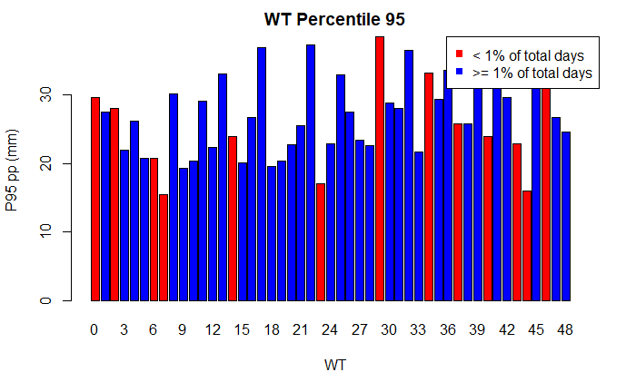

```r
barplot(WT.df$Percentile_95 ~ WT.df$WT, main = "WT Percentile 95", xlab = "WT", ylab = "P95 pp (mm)", col = ifelse((WT.df$Number_of_Days)/sum(WT.df$Number_of_Days)*100 < 1,"red","blue"), na.action = na.pass)
legend("topright", legend = c("< 1% of total days", ">= 1% of total days"),  col = c("red", "blue"), pch = c(15,15))
```

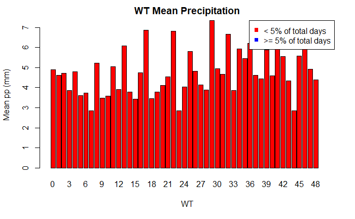

```r
barplot(WT.df$Mean_pp ~ WT.df$WT, main = "WT Mean Precipitation", xlab = "WT", ylab = "Mean pp (mm)", col = ifelse((WT.df$Number_of_Days)/sum(WT.df$Number_of_Days)*100 < 5,"red","blue"), na.action = na.pass)
legend("topright", legend = c("< 5% of total days", ">= 5% of total days"),  col = c("red", "blue"), pch = c(15,15))
```

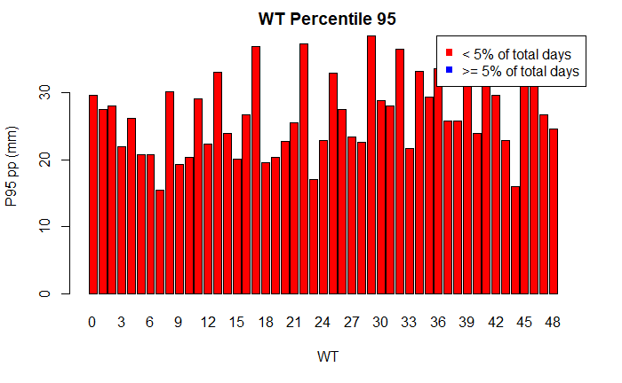

```r
barplot(WT.df$Percentile_95 ~ WT.df$WT, main = "WT Percentile 95", xlab = "WT", ylab = "P95 pp (mm)", col = ifelse((WT.df$Number_of_Days)/sum(WT.df$Number_of_Days)*100 < 5,"red","blue"), na.action = na.pass)
legend("topright", legend = c("< 5% of total days", ">= 5% of total days"),  col = c("red", "blue"), pch = c(15,15))
```

```r
trmm <- bindGrid(trmm160.180, trmm180.210,dimension = "lon")
```

```r
mean.vector <- c()
p95.vector <- c()
counts <- c()
for (i in c(0:49)) {
  if (is.element(i,sort(unique(bmus.df$WT)))) {
    aux <- bmus.df[which(bmus.df$WT == i),]

    c <- length(bmus.df[which(bmus.df$WT == i),]$Date)

    pp.WT <-  trmm$Data[,,match(aux$Date,as.Date(trmm$Dates$start)),,]

    mean.WT <- mean(pp.WT)
    p95.WT <- quantile(pp.WT, .95)

    mean.vector <- c(mean.vector, mean.WT)
    p95.vector <- c(p95.vector, p95.WT)
    counts <- c(counts, c)
  }else{
    mean.vector <- c(mean.vector, NA)
    p95.vector <- c(p95.vector, NA)
    counts <- c(counts, 0)
  }
}
```

```r
data.frame(c(0:49),mean.vector, p95.vector, counts)
```

| c.0.49. | mean.vector | p95.vector | counts |
| --- | --- | --- | --- |
| 0 | 4.892827 | 29.61000 | 2 |
| 1 | 4.622319 | 27.48000 | 271 |
| 2 | 4.706445 | 28.11000 | 78 |
| 3 | 3.868896 | 21.93000 | 117 |
| 4 | 4.793663 | 26.19000 | 88 |
| 5 | 3.614217 | 20.79000 | 372 |
| 6 | 3.720140 | 20.76000 | 39 |
| 7 | 2.841887 | 15.48000 | 48 |
| 8 | 5.209264 | 30.15000 | 220 |
| 9 | 3.482855 | 19.26000 | 143 |

[output cut: 40 more lines]

calculate R01 index, Relative frequency of wet days (precip >= 1mm)

```r
mean.vector <- c()
p95.vector <- c()
counts <- c()
wetdays <- c()
p98wet.vector <- c()
p98wetAmount.vector <- c()


for (i in c(0:49)) {
  if (is.element(i,sort(unique(bmus.df$WT)))) {
    aux <- bmus.df[which(bmus.df$WT == i),]

    c <- length(bmus.df[which(bmus.df$WT == i),]$Date)

    pp.WT <-  trmm$Data[,,match(aux$Date,as.Date(trmm$Dates$start)),,]

    mean.WT <- mean(pp.WT)
    p95.WT <- quantile(pp.WT, .95)
    rf.wetdays.WT <- valueIndex1D(pp.WT,index.codes="R01")
    p98wet <- valueIndex1D(pp.WT,index.codes="P98Wet")
    p98wetAmount <- valueIndex1D(pp.WT,index.codes="P98WetAmount")


    mean.vector <- c(mean.vector, mean.WT)
    p95.vector <- c(p95.vector, p95.WT)
    counts <- c(counts, c)
    wetdays <- c(wetdays, rf.wetdays.WT)
    p98wet.vector <- c(p98wet.vector,p98wet)
    p98wetAmount.vector <- c(p98wetAmount.vector,p98wetAmount)
    ppdays <- c(ppdays,rf.pp.WT)
  }else{
    mean.vector <- c(mean.vector, NA)
    p95.vector <- c(p95.vector, NA)
    counts <- c(counts, 0)
    wetdays <- c(wetdays, NA)
    p98wet.vector <- c(p98wet.vector, NA)
    p98wetAmount.vector <- c(p98wetAmount.vector, NA)

  }
}
```

R01 is the relative frequency of wet days (precip >= 1mm)

```r
WT.df <- data.frame(c(0:49),mean.vector, p95.vector, counts, wetdays, p98wet.vector, p98wetAmount.vector)
colnames(WT.df) <- c("WT", "Mean_pp", "Percentile_95", "Number_of_Days", "R01", "P98Wet", "P98WetAmount")
WT.df
```

| WT | Mean_pp | Percentile_95 | Number_of_Days | R01 | P98Wet | P98WetAmount |
| --- | --- | --- | --- | --- | --- | --- |
| 0 | 4.892827 | 29.61000 | 2 | 0.3303318 | 84.08538 | 36024.30 |
| 1 | 4.622319 | 27.48000 | 271 | 0.3161065 | 73.64999 | 4085636.77 |
| 2 | 4.706445 | 28.11000 | 78 | 0.3044931 | 80.01000 | 1267898.28 |
| 3 | 3.868896 | 21.93000 | 117 | 0.3012314 | 69.89999 | 1733599.27 |
| 4 | 4.793663 | 26.19000 | 88 | 0.3507103 | 77.31000 | 1691861.81 |
| 5 | 3.614217 | 20.79000 | 372 | 0.2963350 | 65.52000 | 4858397.80 |
| 6 | 3.720140 | 20.76000 | 39 | 0.2880607 | 72.09000 | 599793.79 |
| 7 | 2.841887 | 15.48000 | 48 | 0.2840361 | 54.10463 | 512876.89 |
| 8 | 5.209264 | 30.15000 | 220 | 0.3323916 | 80.21999 | 3975601.52 |
| 9 | 3.482855 | 19.26000 | 143 | 0.3056307 | 63.33000 | 1910755.19 |

[output cut: 40 more lines]

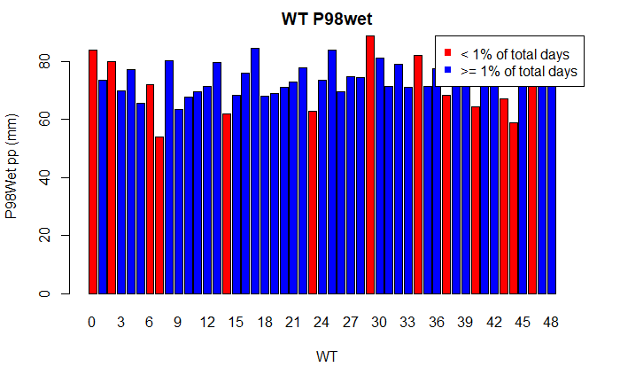

```r
barplot(WT.df$P98Wet ~ WT.df$WT, main = "WT P98wet", xlab = "WT", ylab = "P98Wet pp (mm)", col = ifelse((WT.df$Number_of_Days)/sum(WT.df$Number_of_Days)*100 < 1,"red","blue"), na.action = na.pass)
legend("topright", legend = c("< 1% of total days", ">= 1% of total days"),  col = c("red", "blue"), pch = c(15,15))
```

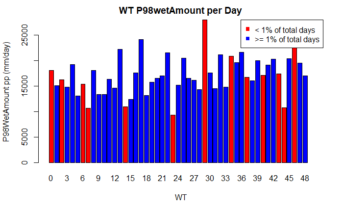

```r
barplot((WT.df$P98WetAmount/WT.df$Number_of_Days) ~ WT.df$WT, main = "WT P98wetAmount per Day", xlab = "WT", ylab = "P98WetAmount pp (mm/day)", col = ifelse((WT.df$Number_of_Days)/sum(WT.df$Number_of_Days)*100 < 1,"red","blue"), na.action = na.pass)
legend("topright", legend = c("< 1% of total days", ">= 1% of total days"),  col = c("red", "blue"), pch = c(15,15))
```

```r
setwd("C:/Users/usuario/Desktop/TRMM-Calibration/Data/W5E5_slp")
```

```
The working directory was changed to C:/Users/usuario/Desktop/TRMM-Calibration/Data/W5E5_slp inside a notebook chunk. The working directory will be reset when the chunk is finished running. Use the knitr root.dir option in the setup chunk to change the working directory for notebook chunks.
```

```r
psl1997.2000 <- bindGrid(loadGridData("psl_W5E5v1.0_19910101-20001231.nc",
                             var = "psl",
                             years = 1997:2000,
                             latLim = c(-30,0),
                             lonLim = c(160,180)),
                         loadGridData("psl_W5E5v1.0_19910101-20001231.nc",
                             var = "psl",
                             years = 1997:2000,
                             latLim = c(-30,0),
                             lonLim = c(-180,-150)), dimension = "lon")
```

```
[2021-02-15 09:25:23] Defining geo-location parameters
[2021-02-15 09:25:23] Defining time selection parameters
[2021-02-15 09:25:23] Retrieving data subset ...
[2021-02-15 09:25:33] Done
[2021-02-15 09:25:33] Defining geo-location parameters
[2021-02-15 09:25:34] Defining time selection parameters
[2021-02-15 09:25:34] Retrieving data subset ...
[2021-02-15 09:25:43] Done
```

```r
setwd("C:/Users/usuario/Desktop/TRMM-Calibration/Data/W5E5_slp")
```

```
The working directory was changed to C:/Users/usuario/Desktop/TRMM-Calibration/Data/W5E5_slp inside a notebook chunk. The working directory will be reset when the chunk is finished running. Use the knitr root.dir option in the setup chunk to change the working directory for notebook chunks.
```

```r
psl2001.2010 <- bindGrid(loadGridData("psl_W5E5v1.0_20010101-20101231.nc",
                             var = "psl",
                             years = 2001:2010,
                             latLim = c(-30,0),
                             lonLim = c(160,180)),
                         loadGridData("psl_W5E5v1.0_20010101-20101231.nc",
                             var = "psl",
                             years = 2001:2010,
                             latLim = c(-30,0),
                             lonLim = c(-180,-150)), dimension = "lon")
```

```
[2021-02-15 09:26:26] Defining geo-location parameters
[2021-02-15 09:26:26] Defining time selection parameters
[2021-02-15 09:26:26] Retrieving data subset ...
[2021-02-15 09:26:46] Done
[2021-02-15 09:26:46] Defining geo-location parameters
[2021-02-15 09:26:46] Defining time selection parameters
[2021-02-15 09:26:46] Retrieving data subset ...
[2021-02-15 09:27:07] Done
```

```r
psl2011.2016 <- bindGrid(loadGridData("psl_W5E5v1.0_20110101-20161231.nc",
                             var = "psl",
                             years = 2011:2016,
                             latLim = c(-30,0),
                             lonLim = c(160,180)),
                         loadGridData("psl_W5E5v1.0_20110101-20161231.nc",
                             var = "psl",
                             years = 2011:2016,
                             latLim = c(-30,0),
                             lonLim = c(-180,-150)), dimension = "lon")
```

```
[2021-02-15 09:27:13] Defining geo-location parameters
[2021-02-15 09:27:13] Defining time selection parameters
[2021-02-15 09:27:13] Retrieving data subset ...
[2021-02-15 09:27:26] Done
[2021-02-15 09:27:26] Defining geo-location parameters
[2021-02-15 09:27:26] Defining time selection parameters
[2021-02-15 09:27:27] Retrieving data subset ...
[2021-02-15 09:27:40] Done
```

```r
psl1997.2016 <- bindGrid(psl1997.2000, psl2001.2010, psl2011.2016, dimension = "time")
```

```r
psl.vector <- c()

for (i in c(0:49)) {
  if (is.element(i,sort(unique(bmus.df$WT)))) {
    aux <- bmus.df[which(bmus.df$WT == i),]

    psl.WT <-  psl1997.2016$Data[match(aux$Date,as.Date(psl1997.2016$Dates$start)),,]

    mean.psl <- mean(psl.WT)

    psl.vector <- c(psl.vector, mean.psl)

  }else{
    psl.vector <- c(psl.vector, NA)
  }
}
```

```r
mean.vector <- c()
p95.vector <- c()
counts <- c()
wetdays <- c()
p98wet.vector <- c()
p98wetAmount.vector <- c()
psl.vector <- c()
trmm2016 <- subsetYears(trmm, years = c(1998:2016))
psl2016 <- subsetYears(psl1997.2016, years = c(1998:2016))
bmus.df.2016 <- bmus.df[which(bmus.df$Date < as.Date("2017/01/01")),]

for (i in c(0:49)) {
  if (is.element(i,sort(unique(bmus.df.2016$WT)))) {
    aux <- bmus.df.2016[which(bmus.df.2016$WT == i),]

    c <- length(bmus.df[which(bmus.df.2016$WT == i),]$Date)


    pp.WT <-  trmm2016$Data[,,match(aux$Date,as.Date(trmm2016$Dates$start)),,]
    psl.WT <-  psl2016$Data[match(aux$Date,as.Date(psl2016$Dates$start)),,]

    mean.WT <- mean(pp.WT, na.rm = TRUE)
    mean.psl <- mean(psl.WT, na.rm = TRUE)
    p95.WT <- quantile(pp.WT, .95, na.rm = TRUE)
    rf.wetdays.WT <- valueIndex1D(pp.WT,index.codes="R01")
    p98wet <- valueIndex1D(pp.WT,index.codes="P98Wet")
    p98wetAmount <- valueIndex1D(pp.WT,index.codes="P98WetAmount")
    psl.vector <- c(psl.vector, mean.psl)

    mean.vector <- c(mean.vector, mean.WT)
    p95.vector <- c(p95.vector, p95.WT)
    counts <- c(counts, c)
    wetdays <- c(wetdays, rf.wetdays.WT)
    p98wet.vector <- c(p98wet.vector,p98wet)
    p98wetAmount.vector <- c(p98wetAmount.vector,p98wetAmount)
  }else{
    mean.vector <- c(mean.vector, NA)
    p95.vector <- c(p95.vector, NA)
    counts <- c(counts, 0)
    wetdays <- c(wetdays, NA)
    p98wet.vector <- c(p98wet.vector, NA)
    p98wetAmount.vector <- c(p98wetAmount.vector, NA)
    psl.vector <- c(psl.vector, NA)
  }
}
```

```r
WT.df.2016 <- data.frame(c(0:49),mean.vector, p95.vector, psl.vector, counts, wetdays, p98wet.vector, p98wetAmount.vector)
colnames(WT.df.2016) <- c("WT", "Mean_pp", "Percentile_95","SLP", "Number_of_Days", "R01", "P98Wet", "P98WetAmount")
WT.df.2016
```

| WT | Mean_pp | Percentile_95 | SLP | Number_of_Days | R01 | P98Wet | P98WetAmount |
| --- | --- | --- | --- | --- | --- | --- | --- |
| 0 | 4.892827 | 29.61 | 101076.1 | 2 | 0.3303318 | 84.08538 | 36024.30 |
| 1 | 4.622319 | 27.48 | 101140.1 | 271 | 0.3161065 | 73.64999 | 4085636.77 |
| 2 | 4.706445 | 28.11 | 101298.0 | 78 | 0.3044931 | 80.01000 | 1267898.28 |
| 3 | 3.868896 | 21.93 | 101369.9 | 117 | 0.3012314 | 69.89999 | 1733599.27 |
| 4 | 4.793663 | 26.19 | 101214.1 | 88 | 0.3507103 | 77.31000 | 1691861.81 |
| 5 | 3.870421 | 21.90 | 101377.4 | 117 | 0.3066169 | 69.87000 | 1722358.55 |
| 6 | 3.720140 | 20.76 | 101286.0 | 39 | 0.2880607 | 72.09000 | 599793.79 |
| 7 | 2.841887 | 15.48 | 101370.6 | 48 | 0.2840361 | 54.10463 | 512876.89 |
| 8 | 5.221937 | 30.24 | 101089.2 | 218 | 0.3324923 | 80.34000 | 3948688.59 |
| 9 | 3.482855 | 19.26 | 101330.8 | 143 | 0.3056307 | 63.33000 | 1910755.19 |

[output cut: 40 more lines]

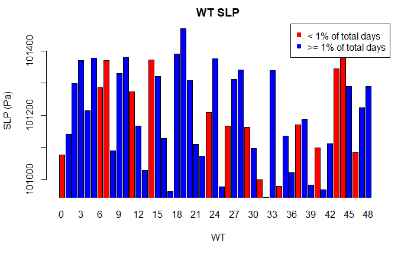

```r
barplot(WT.df.2016$SLP ~ WT.df.2016$WT, main = "WT SLP", xlab = "WT", ylab = "SLP (Pa)", ylim = c(min(WT.df.2016$SLP, na.rm = TRUE),max(WT.df.2016$SLP, na.rm = TRUE)),col = ifelse((WT.df.2016$Number_of_Days)/sum(WT.df.2016$Number_of_Days)*100 < 1,"red","blue"), na.action = na.pass, xpd = FALSE)
legend("topright", legend = c("< 1% of total days", ">= 1% of total days"),  col = c("red", "blue"), pch = c(15,15))
```

```r
diff.psl <- c()
WT.day <- c()
WT.value <- c()
for (i in c(0:49)) {
  if (is.element(i,sort(unique(bmus.df.2016$WT)))) {
    aux <- bmus.df.2016[which(bmus.df.2016$WT == i),]

    psl.WT <-  psl1997.2016$Data[match(aux$Date,as.Date(psl1997.2016$Dates$start)),,]
    psl.WT.days <- psl1997.2016$Dates$start[match(aux$Date,as.Date(psl1997.2016$Dates$start))]
    psl.WT.previous <-  psl1997.2016$Data[match(aux$Date,as.Date(psl1997.2016$Dates$start))-1,,]

    aux.psl <- c()

    if (length(dim(psl.WT)) > 2) {
      iter <- dim(psl.WT)[1]
    }else{
      iter <- 1
    }
    for (j in c(1:iter)) {
      if (iter > 1) {
        aux.mean <- mean(psl.WT[j,,])
        aux.mean.previous <- mean(psl.WT.previous[j,,])
        aux.psl <- c(aux.psl, aux.mean-aux.mean.previous)
      }else{
        aux.mean <- mean(psl.WT)
        aux.mean.previous <- mean(psl.WT.previous)
        aux.psl <- c(aux.psl, aux.mean-aux.mean.previous)
      }

    }
    WT.value <- c(WT.value,rep(i,j)) #repeat WT j times
    WT.day <- c(WT.day,psl.WT.days)
    diff.psl <- c(diff.psl, aux.psl)
  }else{
    diff.psl <- c(diff.psl, NA)
    WT.value <- c(WT.value, i)
    WT.day <- c(WT.day, NA)
  }
}
```

```r
WT.diff.psl <- data.frame(WT.value, as.Date(WT.day, format = "%Y-%m-%d"), diff.psl)
colnames(WT.diff.psl) <- c("WT", "Date", "Diff_PSL")
WT.diff.psl
```

| WT | Date | Diff_PSL |
| --- | --- | --- |
| 0 | 2012-06-04 | -93.8427635 |
| 0 | 2012-06-13 | -65.5418839 |
| 1 | 1998-10-04 | 68.1059741 |
| 1 | 1998-10-05 | 61.0997314 |
| 1 | 1998-10-06 | -62.2774636 |
| 1 | 1998-10-07 | -142.4219308 |
| 1 | 1998-10-08 | -73.6735197 |
| 1 | 1998-10-09 | 69.2493241 |
| 1 | 1998-10-10 | 70.0276398 |
| 1 | 1998-10-11 | 104.2872416 |

[output cut: 990 more lines]

```r
psl.max.diff <- c()
psl.min.diff <- c()

for (i in c(0:49)) {
  if (is.element(i,sort(unique(bmus.df.2016$WT)))) {
    psl.max.diff <- c(psl.max.diff, max(WT.diff.psl[which(WT.diff.psl$WT==i),,]$Diff_PSL))
    psl.min.diff <- c(psl.min.diff, min(WT.diff.psl[which(WT.diff.psl$WT==i),,]$Diff_PSL))

  }else{
    psl.max.diff <- c(psl.max.diff, NA)
    psl.min.diff <- c(psl.min.diff, NA)
  }

}
```

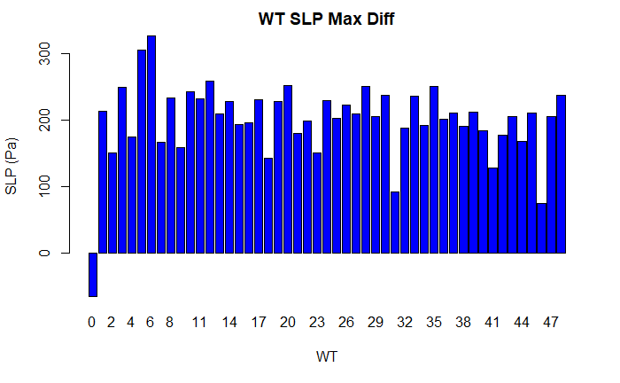

```r
barplot(psl.max.diff ~ c(0:49), main = "WT SLP Max Diff", xlab = "WT", ylab = "SLP (Pa)", col = 'blue')
```

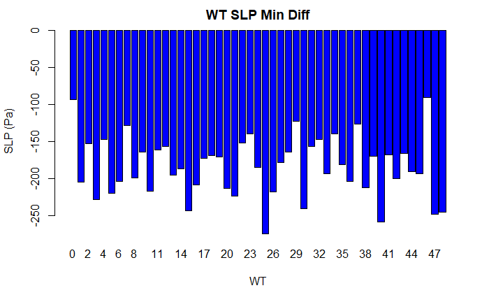

```r
barplot(psl.min.diff ~ c(0:49), main = "WT SLP Min Diff", xlab = "WT", ylab = "SLP (Pa)", col = 'blue')
```

```r
write.csv(WT.diff.psl,"C:/Users/usuario/Desktop/TRMM-Calibration/Data/WT_diff_psl.csv")
```

```r
psl.abs.diff <- c()

for (i in c(0:49)) {
  if (is.element(i,sort(unique(bmus.df.2016$WT)))) {
    psl.abs.diff <- c(psl.abs.diff, mean(abs(WT.diff.psl[which(WT.diff.psl$WT==i),,]$Diff_PSL)))
  }else{
    psl.abs.diff <- c(psl.abs.diff, NA)
  }

}
```

```r
WT.df.2016 <- data.frame(c(0:49),mean.vector, p95.vector, psl.vector, psl.abs.diff, counts, wetdays, p98wet.vector, p98wetAmount.vector)
colnames(WT.df.2016) <- c("WT", "Mean_pp", "Percentile_95","SLP","SLP_Mean_Diff", "Number_of_Days", "R01", "P98Wet", "P98WetAmount")
WT.df.2016
```

| WT | Mean_pp | Percentile_95 | SLP | SLP_Mean_Diff | Number_of_Days | R01 | P98Wet | P98WetAmount |
| --- | --- | --- | --- | --- | --- | --- | --- | --- |
| 0 | 4.892827 | 29.61 | 101076.1 | 79.69232 | 2 | 0.3303318 | 84.08538 | 36024.30 |
| 1 | 4.622319 | 27.48 | 101140.1 | 60.15411 | 271 | 0.3161065 | 73.64999 | 4085636.77 |
| 2 | 4.706445 | 28.11 | 101298.0 | 53.03826 | 78 | 0.3044931 | 80.01000 | 1267898.28 |
| 3 | 3.868896 | 21.93 | 101369.9 | 64.80992 | 117 | 0.3012314 | 69.89999 | 1733599.27 |
| 4 | 4.793663 | 26.19 | 101214.1 | 57.57124 | 88 | 0.3507103 | 77.31000 | 1691861.81 |
| 5 | 3.870421 | 21.90 | 101377.4 | 66.11812 | 117 | 0.3066169 | 69.87000 | 1722358.55 |
| 6 | 3.720140 | 20.76 | 101286.0 | 81.65303 | 39 | 0.2880607 | 72.09000 | 599793.79 |
| 7 | 2.841887 | 15.48 | 101370.6 | 58.54709 | 48 | 0.2840361 | 54.10463 | 512876.89 |
| 8 | 5.221937 | 30.24 | 101089.2 | 58.02942 | 218 | 0.3324923 | 80.34000 | 3948688.59 |
| 9 | 3.482855 | 19.26 | 101330.8 | 59.76434 | 143 | 0.3056307 | 63.33000 | 1910755.19 |

[output cut: 40 more lines]

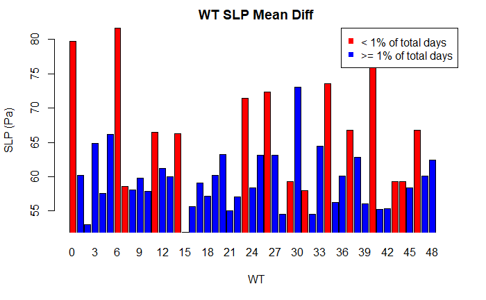

```r
barplot(WT.df.2016$SLP_Mean_Diff ~ WT.df.2016$WT, main = "WT SLP Mean Diff", xlab = "WT", ylab = "SLP (Pa)", ylim = c(min(WT.df.2016$SLP_Mean_Diff, na.rm = TRUE),max(WT.df.2016$SLP_Mean_Diff, na.rm = TRUE)),col = ifelse((WT.df.2016$Number_of_Days)/sum(WT.df.2016$Number_of_Days)*100 < 1,"red","blue"), na.action = na.pass, xpd = FALSE)
legend("topright", legend = c("< 1% of total days", ">= 1% of total days"),  col = c("red", "blue"), pch = c(15,15))
```

```r
write.csv(WT.df.2016,"C:/Users/usuario/Desktop/TRMM-Calibration/Data/WT_1998_2016.csv")
```

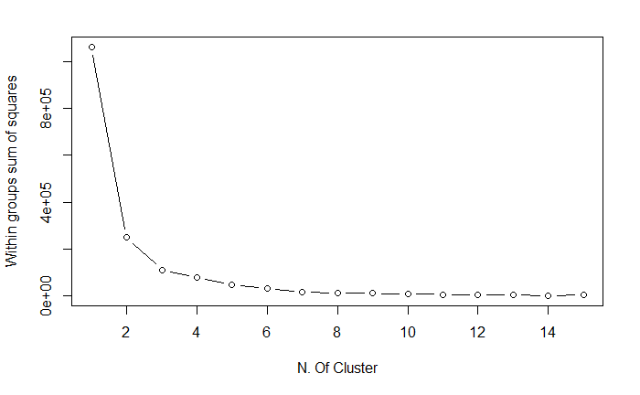

```r
totWithinss <- c(1:15)
for(i in 1:15){
  kmModel<- kmeans(na.omit(WT.df.2016[,c(2,3,4,7)]), centers = i, nstart = 1)
  totWithinss[i]<- kmModel$tot.withinss
}
plot(x=1:15,y=totWithinss,type="b", xlab="N. Of Cluster",ylab="Within groups sum of squares")
```

```r
kmModel <- kmeans(na.omit(WT.df.2016[,c(2,3,4,7)]), centers = 4)
summary(kmModel)
```

```
             Length Class  Mode
cluster      49     -none- numeric
centers      16     -none- numeric
totss         1     -none- numeric
withinss      4     -none- numeric
tot.withinss  1     -none- numeric
betweenss     1     -none- numeric
size          4     -none- numeric
iter          1     -none- numeric
ifault        1     -none- numeric
```

```r
plot(na.omit(WT.df.2016[,c(2,4)]),col=kmModel$cluster,main="KMeans", pch = 16)
text(na.omit(WT.df.2016[,c(2,4)]), as.character(na.omit(WT.df.2016[,1])), cex = 0.75, pos = 2)
```

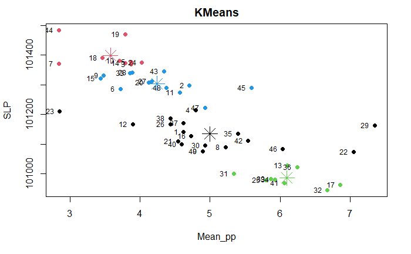

```r
points(kmModel$centers[,c(1,3)],col=1:4,pch=8,cex=2.5)
```

```r
plot(na.omit(WT.df.2016[,c(3,4)]),col=kmModel$cluster,main="KMeans", pch = 16)
text(na.omit(WT.df.2016[,c(3,4)]), as.character(sort(unique(bmus.df$WT))), cex = 0.75, pos = 2)
```

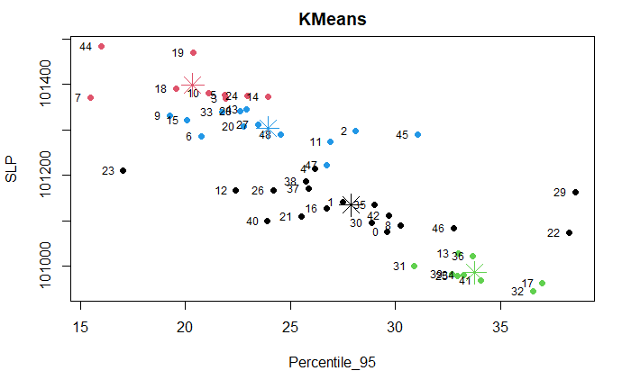

```r
points(kmModel$centers[,c(2,3)],col=1:4,pch=8,cex=2.5)
```

```r
plot(na.omit(WT.df.2016[,c(2,7)]),col=kmModel$cluster,main="KMeans", pch = 16)
text(na.omit(WT.df.2016[,c(2,7)]), as.character(sort(unique(bmus.df$WT))), cex = 0.75, pos = 2)
```

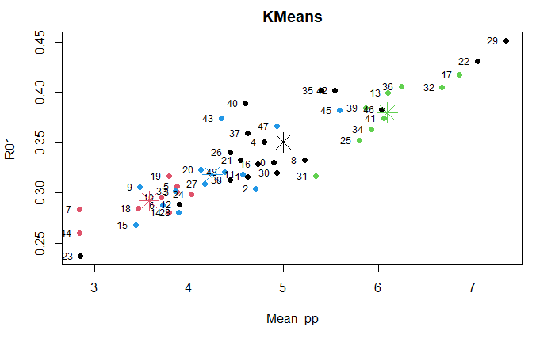

```r
points(kmModel$centers[,c(1,4)],col=1:4,pch=8,cex=2.5)
```

```r
plot(na.omit(WT.df.2016[,c(2,3,4,7)]),col=kmModel$cluster,main="KMeans", pch = 16)
text(na.omit(WT.df.2016[,c(2,3,4,7)]), as.character(sort(unique(bmus.df$WT))), cex = 0.75, pos = 2)
```

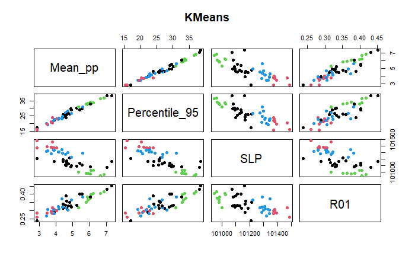

```r
points(kmModel$centers,col=1:4,pch=8,cex=2.5)
```

```r
WT.scaled <- scale(WT.df.2016[,-1])
```

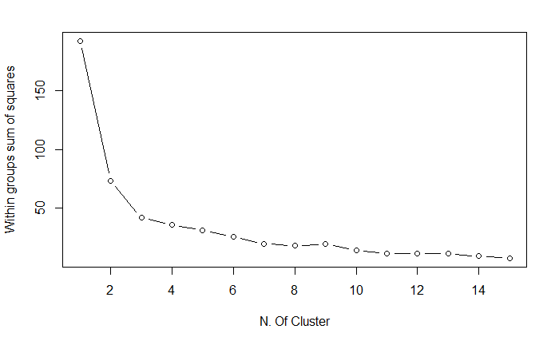

```r
totWithinss <- c(1:15)
for(i in 1:15){
  kmModel<- kmeans(na.omit(WT.scaled[,c(1,2,3,6)]), centers = i, nstart = 1)
  totWithinss[i]<- kmModel$tot.withinss
}
plot(x=1:15,y=totWithinss,type="b", xlab="N. Of Cluster",ylab="Within groups sum of squares")
```

```r
kmModel <- kmeans(na.omit(WT.scaled[,c(1,2,3,6)]), centers = 4)
summary(kmModel)
```

```
             Length Class  Mode
cluster      49     -none- numeric
centers      16     -none- numeric
totss         1     -none- numeric
withinss      4     -none- numeric
tot.withinss  1     -none- numeric
betweenss     1     -none- numeric
size          4     -none- numeric
iter          1     -none- numeric
ifault        1     -none- numeric
```

```r
plot(na.omit(WT.scaled[,c(1,3)]),col=kmModel$cluster,main="KMeans", pch = 16)
text(na.omit(WT.scaled[,c(1,3)]), as.character(sort(unique(bmus.df$WT))), cex = 0.75, pos = 2)
```

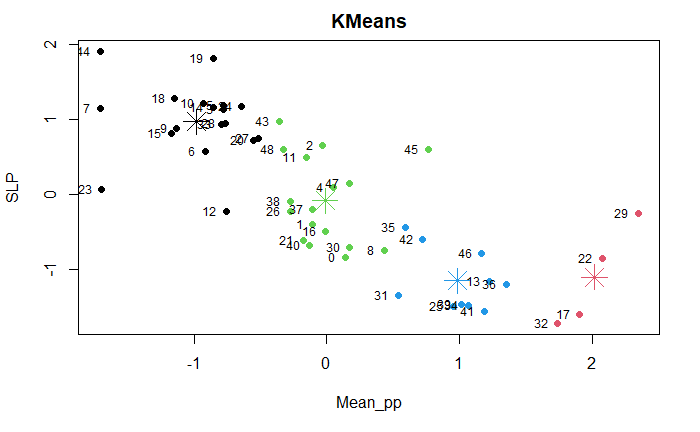

```r
points(kmModel$centers[,c(1,3)],col=1:4,pch=8,cex=2.5)
```

```r
plot(na.omit(WT.scaled[,c(2,3)]),col=kmModel$cluster,main="KMeans", pch = 16)
text(na.omit(WT.scaled[,c(2,3)]), as.character(sort(unique(bmus.df$WT))), cex = 0.75, pos = 2)
```

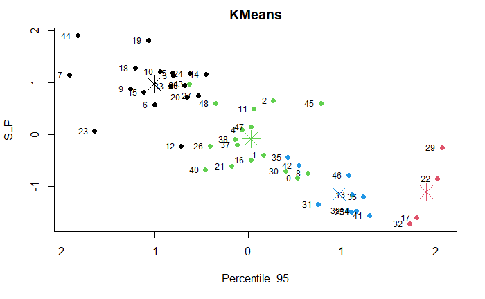

```r
points(kmModel$centers[,c(2,3)],col=1:4,pch=8,cex=2.5)
```

```r
plot(na.omit(WT.scaled[,c(1,6)]),col=kmModel$cluster,main="KMeans", pch = 16)
text(na.omit(WT.scaled[,c(1,6)]), as.character(sort(unique(bmus.df$WT))), cex = 0.75, pos = 2)
```

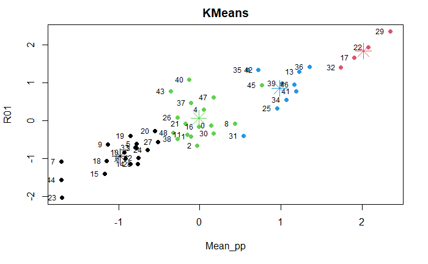

```r
points(kmModel$centers[,c(1,4)],col=1:4,pch=8,cex=2.5)
```

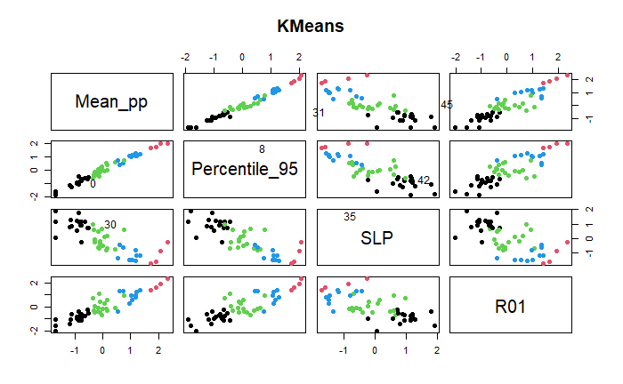

```r
WT.scaled <- as.data.frame(WT.scaled)

plot(na.omit(WT.scaled[,c(1,2,3,6)]),col=kmModel$cluster,main="KMeans", pch = 16)
text(na.omit(WT.scaled[,c(1,2,3,6)]), as.character(sort(unique(bmus.df$WT))), cex = 0.75, pos = 2)
```

```r
setwd("C:/Users/usuario/Desktop/TRMM-Calibration/Data")
```

```
The working directory was changed to C:/Users/usuario/Desktop/TRMM-Calibration/Data inside a notebook chunk. The working directory will be reset when the chunk is finished running. Use the knitr root.dir option in the setup chunk to change the working directory for notebook chunks.
```

```r
rain <- read.csv('rain.txt')
```

#Station selection

```r
rain
```

| site_identifier | timestamp | period | amount | flags | recotd_identifier | record_timestamp |
| --- | --- | --- | --- | --- | --- | --- |
| US03146 | 2017-05-06T22:00:00.0 | 24 | 0.000 | 16 | 6800192 | 2017-08-30T20:01:36 |
| US03146 | 2017-04-06T22:00:00.0 | 24 | 0.000 | 16 | 6800193 | 2017-08-30T20:01:36 |
| US03146 | 2017-07-30T22:00:00.0 | 24 | 0.000 | 16 | 6800194 | 2017-08-30T20:01:36 |
| US03146 | 2017-06-06T22:00:00.0 | 24 | 0.000 | 16 | 6800195 | 2017-08-30T20:01:36 |
| US03146 | 2017-05-21T22:00:00.0 | 24 | 0.000 | 16 | 6800196 | 2017-08-30T20:01:36 |
| US03146 | 2017-04-23T22:00:00.0 | 24 | 0.000 | 16 | 6800197 | 2017-08-30T20:01:36 |
| US03146 | 2017-05-14T22:00:00.0 | 24 | 0.000 | 16 | 6800198 | 2017-08-30T20:01:36 |
| US03146 | 2017-07-09T22:00:00.0 | 24 | 0.000 | 16 | 6800199 | 2017-08-30T20:01:36 |
| US03146 | 2017-04-14T22:00:00.0 | 24 | 0.000 | 16 | 6800200 | 2017-08-30T20:01:36 |
| US03146 | 2017-06-23T22:00:00.0 | 24 | 0.300 | 16 | 6800201 | 2017-08-30T20:01:36 |

[output cut: 990 more lines]

```r
rain <- rain[rain$timestamp > "1998-01-01",]
rain <- rain[rain$timestamp <= "2019-12-31",]
rain
```

|  | site_identifier | timestamp | period | amount | flags | recotd_identifier | record_timestamp |
| --- | --- | --- | --- | --- | --- | --- | --- |
| 1 | US03146 | 2017-05-06T22:00:00.0 | 24 | 0.000 | 16 | 6800192 | 2017-08-30T20:01:36 |
| 2 | US03146 | 2017-04-06T22:00:00.0 | 24 | 0.000 | 16 | 6800193 | 2017-08-30T20:01:36 |
| 3 | US03146 | 2017-07-30T22:00:00.0 | 24 | 0.000 | 16 | 6800194 | 2017-08-30T20:01:36 |
| 4 | US03146 | 2017-06-06T22:00:00.0 | 24 | 0.000 | 16 | 6800195 | 2017-08-30T20:01:36 |
| 5 | US03146 | 2017-05-21T22:00:00.0 | 24 | 0.000 | 16 | 6800196 | 2017-08-30T20:01:36 |
| 6 | US03146 | 2017-04-23T22:00:00.0 | 24 | 0.000 | 16 | 6800197 | 2017-08-30T20:01:36 |
| 7 | US03146 | 2017-05-14T22:00:00.0 | 24 | 0.000 | 16 | 6800198 | 2017-08-30T20:01:36 |
| 8 | US03146 | 2017-07-09T22:00:00.0 | 24 | 0.000 | 16 | 6800199 | 2017-08-30T20:01:36 |
| 9 | US03146 | 2017-04-14T22:00:00.0 | 24 | 0.000 | 16 | 6800200 | 2017-08-30T20:01:36 |
| 10 | US03146 | 2017-06-23T22:00:00.0 | 24 | 0.300 | 16 | 6800201 | 2017-08-30T20:01:36 |

[output cut: 990 more lines]

```r
counts <- c()
code.st <- c()
for (i in c(1:length(unique(sites$site_identifier)))) {
  location <- unique(sites$site_identifier)[i]
  code.st <- c(code.st,location)
  counts <- c(counts,dim(rain[which(rain$site_identifier == location),])[1])
}
```

```r
data.frame(code.st, counts)
```

| code.st | counts |
| --- | --- |
| NZ50700 | 2610 |
| NZ52000 | 2156 |
| NZ52700 | 720 |
| NZ53300 | 304 |
| NZ54100 | 2499 |
| NZ55100 | 3030 |
| NZ55400 | 2845 |
| NZ55500 | 2668 |
| NZ55700 | 3208 |
| FJ00002 | 2191 |

[output cut: 294 more lines]

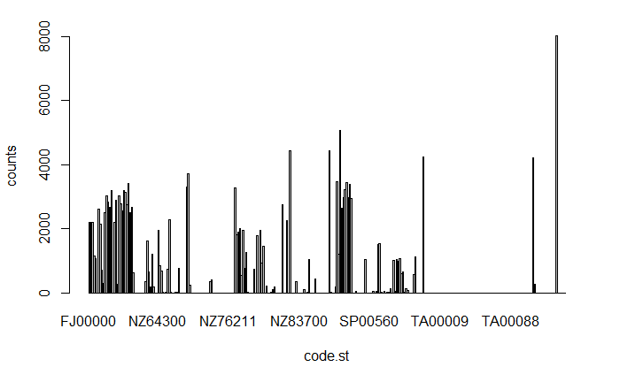

```r
barplot(counts ~ code.st)
```

```r
code.st[which(counts > 3650)]
```

```
[1] "NZ75400" "NZ82400" "NZ84317" "NZ99701" "SP00646" "US14000" "US14690"
```

```r
station.df <- c()
for (i in c(1:length(code.st[which(counts > 3650)]))) {
  newstation <- rain[which(rain$site_identifier ==  code.st[which(counts > 3650)][i]),]
  station.df <- rbind(station.df, newstation)
}

for (i in which(station.df$period > 24)) {
  aux <- station.df$period[i] / 24
  station.df$amount[i] <- station.df$amount[i] / aux
  station.df$period[i] <- 24
}
station.df
```

|  | site_identifier | timestamp | period | amount | flags | recotd_identifier | record_timestamp |
| --- | --- | --- | --- | --- | --- | --- | --- |
| 326582 | NZ75400 | 1998-01-01T21:00:00.0 | 24 | 0.4 | 0 | 5929921 | 2015-03-27T00:31:55 |
| 326583 | NZ75400 | 1998-01-03T21:00:00.0 | 24 | 2.0 | 0 | 5929922 | 2015-03-27T00:31:55 |
| 326584 | NZ75400 | 1998-01-04T21:00:00.0 | 24 | 36.0 | 0 | 5929923 | 2015-03-27T00:31:55 |
| 326585 | NZ75400 | 1998-01-05T21:00:00.0 | 24 | 27.0 | 0 | 5929924 | 2015-03-27T00:31:55 |
| 326586 | NZ75400 | 1998-01-06T21:00:00.0 | 24 | 1.0 | 0 | 5929925 | 2015-03-27T00:31:55 |
| 326587 | NZ75400 | 1998-01-07T21:00:00.0 | 24 | 14.0 | 0 | 5929926 | 2015-03-27T00:31:55 |
| 326588 | NZ75400 | 1998-01-08T21:00:00.0 | 24 | 5.0 | 0 | 5929927 | 2015-03-27T00:31:55 |
| 326589 | NZ75400 | 1998-01-09T21:00:00.0 | 24 | 15.0 | 0 | 5929928 | 2015-03-27T00:31:55 |
| 326590 | NZ75400 | 1998-01-10T21:00:00.0 | 24 | 17.0 | 0 | 5929929 | 2015-03-27T00:31:55 |
| 326591 | NZ75400 | 1998-01-11T21:00:00.0 | 24 | 1.0 | 0 | 5929930 | 2015-03-27T00:31:55 |

[output cut: 990 more lines]

```r
percentage.missing <- c()

for (i in c(1:length(unique(station.df$site_identifier)))) {
  percentage.missing <- c(percentage.missing,100 - (length(station.df[station.df$site_identifier ==unique(station.df$site_identifier)[i],]$timestamp)/as.numeric((as.Date(max(station.df[station.df$site_identifier ==unique(station.df$site_identifier)[i],]$timestamp), format = "%Y-%m-%d")-as.Date(min(station.df[station.df$site_identifier ==unique(station.df$site_identifier)[i],]$timestamp), format = "%Y-%m-%d")))*100))
}

data.frame(unique(station.df$site_identifier), percentage.missing)
```

| unique.station.df.site_identifier. | percentage.missing |
| --- | --- |
| NZ75400 | 27.15179969 |
| NZ82400 | 3.82619974 |
| NZ84317 | 1.20589549 |
| NZ99701 | 0.68466354 |
| SP00646 | 12.98727944 |
| US14000 | 21.24719940 |
| US14690 | 0.01244865 |

# Creation of Standart (ASCII) format for station data

First, stations.txt is created.

```r
lon.vector <- c()
lat.vector <- c()
alt.vector <- c()

for (i in c(1:length(unique(station.df$site_identifier)))) {
  lon.vector <- c(lon.vector,sites[which(sites$site_identifier ==unique(station.df$site_identifier)[i] ),]$longitude)
  lat.vector <- c(lat.vector,sites[which(sites$site_identifier ==unique(station.df$site_identifier)[i] ),]$latitude)
  alt.vector <- c(alt.vector,sites[which(sites$site_identifier ==unique(station.df$site_identifier)[i] ),]$elevation)
}

stations.ascii <- data.frame(unique(station.df$site_identifier),lon.vector, lat.vector, alt.vector)
colnames(stations.ascii) <- c("station_id", "longitude", "latitude", "altitude")
```

```r
stations.ascii
```

| station_id | longitude | latitude | altitude |
| --- | --- | --- | --- |
| NZ75400 | -178.117 | -14.3167 | 36 |
| NZ82400 | -169.933 | -19.0667 | 59 |
| NZ84317 | -159.800 | -21.2000 | 4 |
| NZ99701 | -177.933 | -29.2333 | 49 |
| SP00646 | -168.300 | -17.7167 | 24 |
| US14000 | -170.767 | -14.3000 | 408 |
| US14690 | -170.700 | -14.3167 | 3 |

```r
write.table(stations.ascii,"C:/Users/usuario/Desktop/TRMM-Calibration/Data/SP_ascii/stations.txt", row.names = F, sep = ",", quote = F, na = "NaN")
```

Then, variables.txt must be created

```r
vars <- data.frame(c("precip_obs","precip_trmm","slp"),c("Total_observated_precipitation_accumulated_in_24_hours","Total_TRMM_precipitation_accumulated_in_24_hours","Sea_level_air_pressure"),c("mm","mm","Pa"),c("NaN","NaN","NaN"),c("observation","satellite", "reanalysis"))

colnames(vars)<- c("variable_id", "name", "unit", "missing_code", "type")
vars
```

| variable_id | name | unit | missing_code | type |
| --- | --- | --- | --- | --- |
| precip_obs | Total_observated_precipitation_accumulated_in_24_hours | mm | NaN | observation |
| precip_trmm | Total_TRMM_precipitation_accumulated_in_24_hours | mm | NaN | satellite |
| slp | Sea_level_air_pressure | Pa | NaN | reanalysis |

```r
write.table(vars,"C:/Users/usuario/Desktop/TRMM-Calibration/Data/SP_ascii/variables.txt", row.names = F, sep = ",", quote = F, na = "NaN")
```

Now, for each variable, we must create a data file. For example, for observational precipitation we need a precip_obs.txt. In this file there exist the column of the date and one column for each station. So each record contains the date and the values of observed precipitation in each station for that date.

```r
date.record <- c()
for (i in c(1:length(unique(as.Date(station.df$timestamp, format = "%Y-%m-%d"))))) {
  station.values <- c()
  for (j in c(1:length(unique(station.df$site_identifier)))) {
    aux.st <- station.df[station.df$site_identifier == unique(station.df$site_identifier)[j],]
    aux.st <- aux.st[as.Date(aux.st$timestamp,format = "%Y-%m-%d") == as.Date(station.df$timestamp, format = "%Y-%m-%d")[i],]
    if (dim(aux.st)[1] > 0) {
      station.values <- c(station.values, aux.st$amount)
    }else{
      station.values <- c(station.values, NaN)
    }
  }
  date.record <- rbind(date.record, station.values)
}
```

[output not shown]

```r
#sort(unique(as.Date(station.df$timestamp, format = "%Y-%m-%d")))
```

```r
pp_obs <- data.frame(unique(as.Date(station.df$timestamp, format = "%Y-%m-%d")), date.record)
rownames(pp_obs) <- NULL
colnames(pp_obs) <- c("YYYYMMDD",unique(station.df$site_identifier))
pp_obs <- pp_obs[order(pp_obs$YYYYMMDD),]
pp_obs$YYYYMMDD <- paste(substr(pp_obs$YYYYMMDD,start = 1,stop = 4),substr(pp_obs$YYYYMMDD,start = 6,stop = 7), substr(pp_obs$YYYYMMDD,start = 9,stop = 10),sep = "")
pp_obs
```

|  | YYYYMMDD | NZ75400 | NZ82400 | NZ84317 | NZ99701 | SP00646 | US14000 | US14690 |
| --- | --- | --- | --- | --- | --- | --- | --- | --- |
| 1 | 19980101 | 0.4 | 0.8 | NaN | 1.4 | NaN | 0.0 | 0.0 |
| 3725 | 19980102 | 0.4 | 0.8 | NaN | 1.4 | NaN | 0.0 | 0.0 |
| 2 | 19980103 | 2.0 | 9.5 | NaN | 0.0 | NaN | 69.6 | 3.0 |
| 3 | 19980104 | 36.0 | 1.5 | NaN | 1.4 | NaN | 0.0 | 11.7 |
| 4 | 19980105 | 27.0 | 0.0 | NaN | 8.8 | NaN | 50.0 | 22.9 |
| 5 | 19980106 | 1.0 | 2.4 | NaN | 0.0 | NaN | 0.0 | 21.3 |
| 6 | 19980107 | 14.0 | 1.5 | NaN | 5.4 | NaN | 20.3 | 3.0 |
| 7 | 19980108 | 5.0 | 5.9 | NaN | 153.6 | NaN | 0.0 | 6.6 |
| 8 | 19980109 | 15.0 | 1.1 | NaN | 27.8 | NaN | 0.0 | 0.0 |
| 9 | 19980110 | 17.0 | 0.0 | NaN | 0.0 | NaN | 0.0 | 0.0 |

[output cut: 990 more lines]

```r
write.table(pp_obs,"C:/Users/usuario/Desktop/TRMM-Calibration/Data/SP_ascii/precip_obs.txt", row.names = F, sep = ",", quote = F, na = "NaN")
```

```r
#pp_obs <- read.csv("C:/Users/usuario/Desktop/TRMM-Calibration/Data/SP_ascii/pp_obs.txt")
#stations.chars <- read.csv("C:/Users/usuario/Desktop/TRMM-Calibration/Data/SP_ascii/stations.txt")
idx <- which.min(abs(trmm$xyCoords$x - stations.chars$longitude))
lon <- trmm$xyCoords$x[idx]

idx2 <- which.min(abs(trmm$xyCoords$y - stations.chars$latitude))
lat <- trmm$xyCoords$y[idx2]

trmm.station <- subsetGrid(trmm, lonLim = lon, latLim = lat)
```

```r
dates <- paste(substr(trmm$Dates$start,start = 1,stop = 4),substr(trmm$Dates$start,start = 6,stop = 7), substr(trmm$Dates$start,start = 9,stop = 10),sep = "")

date.record <- c(dates)

for (j in c(1:length(stations.chars$latitude))) {
  idx <- which.min(abs(trmm$xyCoords$x - stations.chars$longitude[j]))
  lon <- trmm$xyCoords$x[idx]

  idx2 <- which.min(abs(trmm$xyCoords$y - stations.chars$latitude[j]))
  lat <- trmm$xyCoords$y[idx2]

  trmm.station <- subsetGrid(trmm, lonLim = lon, latLim = lat)

  date.record <- cbind(date.record, trmm.station$Data)

}
pp_trmm <- as.data.frame(date.record)
colnames(pp_trmm) <-  c("YYYYMMDD",unique(station.df$site_identifier))
pp_trmm
```

| YYYYMMDD | NZ75400 | NZ82400 | NZ84317 | NZ99701 | SP00646 | US14000 | US14690 |
| --- | --- | --- | --- | --- | --- | --- | --- |
| 19980101 | 5.67000007629395 | 0 | 0.0899999961256981 | 0.329999983310699 | 6.44999980926514 | 5.34000015258789 | 8.03999996185303 |
| 19980102 | 20.4599990844727 | 0 | 2.42999982833862 | 0 | 6.41999959945679 | 16.4699993133545 | 17.1900005340576 |
| 19980103 | 22.0200004577637 | 0.449999988079071 | 0 | 0.239999994635582 | 11.5499992370605 | 21.9899978637695 | 22.9799976348877 |
| 19980104 | 10.3199996948242 | 0.599999964237213 | 3.11999988555908 | 0 | 21.7799987792969 | 78.629997253418 | 60.689998626709 |
| 19980105 | 9.75 | 4.28999996185303 | 0.119999997317791 | 0 | 22.439998626709 | 179.459991455078 | 174.75 |
| 19980106 | 7.58999919891357 | 34.4099960327148 | 10.4700012207031 | 0.0599999986588955 | 85.5599975585938 | 78.629997253418 | 99.1500091552734 |
| 19980107 | 25.1099967956543 | 6.59999942779541 | 7.44000005722046 | 0 | 31.439998626709 | 7.71000003814697 | 8.96999931335449 |
| 19980108 | 80.2200012207031 | 0.269999980926514 | 32.1600036621094 | 0 | 1.19999992847443 | 7.67999982833862 | 7.83000040054321 |
| 19980109 | 32.8199996948242 | 0.419999957084656 | 0 | 0.509999990463257 | 0.75 | 4.64999961853027 | 5.46000003814697 |
| 19980110 | 165.65998840332 | 1.61999988555908 | 0 | 0.719999969005585 | 2.51999998092651 | 3.56999945640564 | 3.3600001335144 |

[output cut: 990 more lines]

```r
write.table(pp_trmm,"C:/Users/usuario/Desktop/TRMM-Calibration/Data/SP_ascii/precip_trmm.txt", row.names = F, sep = ",", quote = F, na = "NaN")
```

```r
dates <- paste(substr(psl1997.2016$Dates$start,start = 1,stop = 4),substr(psl1997.2016$Dates$start,start = 6,stop = 7), substr(psl1997.2016$Dates$start,start = 9,stop = 10),sep = "")

date.record <- c(dates)

for (j in c(1:length(stations.chars$latitude))) {
  idx <- which.min(abs(psl1997.2016$xyCoords$x - stations.chars$longitude[j]))
  lon <- psl1997.2016$xyCoords$x[idx]

  idx2 <- which.min(abs(psl1997.2016$xyCoords$y - stations.chars$latitude[j]))
  lat <- psl1997.2016$xyCoords$y[idx2]

  psl.station <- subsetGrid(psl1997.2016, lonLim = lon, latLim = lat)

  date.record <- cbind(date.record, psl.station$Data)

}


slp <- as.data.frame(date.record)
colnames(slp) <-  c("YYYYMMDD",unique(station.df$site_identifier))
slp
```

| YYYYMMDD | NZ75400 | NZ82400 | NZ84317 | NZ99701 | SP00646 | US14000 | US14690 |
| --- | --- | --- | --- | --- | --- | --- | --- |
| 19970101 | 100945.0078125 | 101068.8828125 | 101132.8203125 | 101724.4375 | 100949.640625 | 100828.8984375 | 100828.8984375 |
| 19970102 | 100855.09375 | 100932.7421875 | 101206.9375 | 101948.0859375 | 100793.2109375 | 100523.453125 | 100523.453125 |
| 19970103 | 100438.640625 | 100913.15625 | 101163.546875 | 102034.5859375 | 100855.7265625 | 100591.890625 | 100591.890625 |
| 19970104 | 99855.8125 | 100849.8828125 | 100958.0703125 | 101994.515625 | 100802.9609375 | 100720.9609375 | 100720.9609375 |
| 19970105 | 100238.5859375 | 100930.28125 | 100907.8515625 | 101911.859375 | 100884.8203125 | 100839.796875 | 100839.796875 |
| 19970106 | 100272.4296875 | 100914.90625 | 101104.875 | 101571.78125 | 100928.1015625 | 100873.3125 | 100873.3125 |
| 19970107 | 100359.7734375 | 100634.8515625 | 101138.75 | 101003.8828125 | 100762.8203125 | 100735.296875 | 100735.296875 |
| 19970108 | 100653.03125 | 100489.7421875 | 101103.859375 | 100695.6328125 | 100665.9765625 | 100671.7109375 | 100671.7109375 |
| 19970109 | 100792.765625 | 100700.609375 | 100999.84375 | 100547.8046875 | 100755.4765625 | 100721.6875 | 100721.6875 |
| 19970110 | 100838.28125 | 100870.515625 | 101000.25 | 101187.40625 | 100865.7109375 | 100813.1328125 | 100813.1328125 |

[output cut: 990 more lines]

```r
write.table(slp,"C:/Users/usuario/Desktop/TRMM-Calibration/Data/SP_ascii/slp.txt", quote = F ,row.names = F, sep = ",", na = "NaN")
```

Example of reading dataset generated with loadStationData

```r
example <- loadStationData("C:/Users/usuario/Desktop/TRMM-Calibration/Data/SP_ascii", var = "precip_trmm")
```

```
[2021-02-19 11:25:58] Loading data ...
[2021-02-19 11:25:58] Retrieving metadata ...
the condition has length > 1 and only the first element will be used[2021-02-19 11:25:59] Done.
```

```r
str(example)
```

```
List of 5
 $ Variable:List of 2
  ..$ varName: chr "precip_trmm"
  ..$ level  : NULL
  ..- attr(*, "units")= chr "mm"
 $ Data    : num [1:8035, 1:7] 5.67 20.46 22.02 10.32 9.75 ...
  ..- attr(*, "dimensions")= chr [1:2] "time" "loc"
 $ xyCoords:'data.frame':   7 obs. of  2 variables:
  ..$ x: num [1:7] -178 -170 -160 -178 -168 ...
  ..$ y: num [1:7] -14.3 -19.1 -21.2 -29.2 -17.7 ...
  ..- attr(*, "projection")= chr "+proj=longlat +init=epsg:4326 +datum=WGS84 +no_defs +ellps=WGS84 +towgs84=0,0,0"
  ..- attr(*, "resX")= num 0
  ..- attr(*, "resY")= num 0
 $ Dates   :List of 2
  ..$ start: chr [1:8035] "1998-01-01 00:00:00" "1998-01-02 00:00:00" "1998-01-03 00:00:00" "1998-01-04 00:00:00" ...
  ..$ end  : chr [1:8035] "1998-01-02 00:00:00" "1998-01-03 00:00:00" "1998-01-04 00:00:00" "1998-01-05 00:00:00" ...
 $ Metadata:List of 2
  ..$ station_id: chr [1:7] "NZ75400" "NZ82400" "NZ84317" "NZ99701" ...
  ..$ altitude  : int [1:7] 36 59 4 49 24 408 3
 - attr(*, "dataset")= chr "C:/Users/usuario/Desktop/TRMM-Calibration/Data/SP_ascii"
 - attr(*, "R_package_desc")= chr "loadeR-v1.7.0"
 - attr(*, "R_package_URL")= chr "https://github.com/SantanderMetGroup/loadeR"
 - attr(*, "R_package_ref")= chr "https://doi.org/10.1016/j.envsoft.2018.09.009"
```

Computation of precipitation and slp time series for a concrete location

```r
precip_trmm <- loadStationData("C:/Users/usuario/Desktop/TRMM-Calibration/Data/SP_ascii", var = "precip_trmm")
```

```
[2021-02-22 09:23:49] Loading data ...
[2021-02-22 09:23:49] Retrieving metadata ...
the condition has length > 1 and only the first element will be used[2021-02-22 09:23:50] Done.
```

```r
precip_obs <- loadStationData("C:/Users/usuario/Desktop/TRMM-Calibration/Data/SP_ascii", var = "precip_obs")
```

```
[2021-02-22 09:23:50] Loading data ...
[2021-02-22 09:23:50] Retrieving metadata ...
the condition has length > 1 and only the first element will be used[2021-02-22 09:23:51] Done.
```

```r
slp <- loadStationData("C:/Users/usuario/Desktop/TRMM-Calibration/Data/SP_ascii", var = "slp")
```

```
[2021-02-22 09:23:51] Loading data ...
[2021-02-22 09:23:51] Retrieving metadata ...
the condition has length > 1 and only the first element will be used[2021-02-22 09:23:52] Done.
```

```r
wallis.futuna.trmm <- subsetGrid(precip_trmm, station.id = precip_trmm$Metadata$station_id[1])
wallis.futuna.obs <- subsetGrid(precip_obs, station.id = precip_trmm$Metadata$station_id[1])
wallis.futuna.slp <- subsetGrid(slp, station.id = precip_trmm$Metadata$station_id[1])
```

```
pad applied on the interval: day
pad applied on the interval: day
```

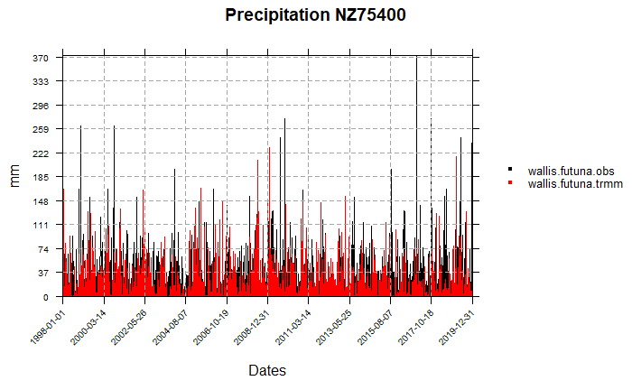

```r
temporalPlot(wallis.futuna.obs,wallis.futuna.trmm, xyplot.custom = list(main = paste("Precipitation",wallis.futuna.trmm$Metadata$station_id), ylab = "mm"))
```

```
pad applied on the interval: day
```

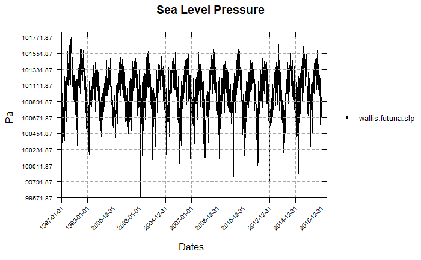

```r
temporalPlot(wallis.futuna.slp, xyplot.custom = list(main = "Sea Level Pressure", ylab = "Pa"))
```

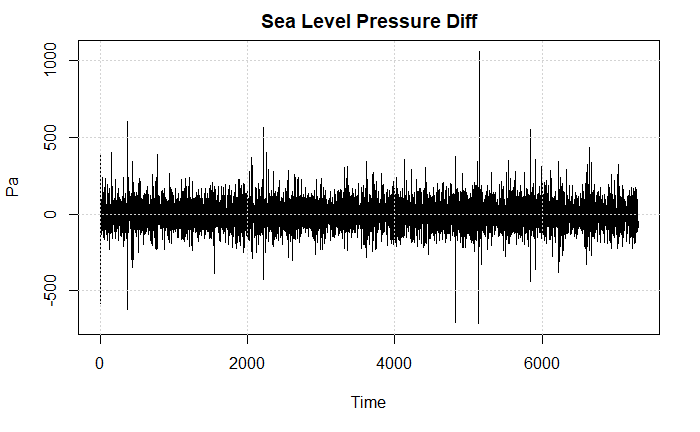

```r
ts.plot(diff(wallis.futuna.slp$Data), gpars = list(main = "Sea Level Pressure Diff", ylab = "Pa"))
grid()
```

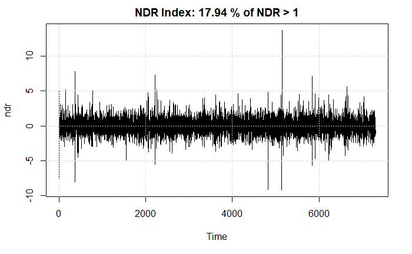

```r
ndr <- (diff(wallis.futuna.slp$Data)*sin(60))/(24*sin(wallis.futuna.slp$xyCoords$y))

ts.plot(ndr, gpars = list(main = paste("NDR Index:", as.character(formatC((length(ndr[ndr > 1])/length(ndr))*100), digits = 3), "% of NDR > 1")))
grid()
```

```r
trmm.aux <- subsetYears(wallis.futuna.trmm, years = 1998:2016)
obs.aux <- subsetYears(wallis.futuna.obs, years = 1998:2016)
slp.aux <- subsetYears(wallis.futuna.slp, years = 1998:2016)
diff.slp.aux <- diff(wallis.futuna.slp$Data)
diff.slp.aux <- diff.slp.aux[(length(diff.slp.aux)-length(slp.aux$Data)+1):length(diff.slp.aux)]
ndr.aux <- (diff.slp.aux*sin(60))/(24*sin(slp.aux$xyCoords$y))
```

```r
station.df <- data.frame(trmm.aux$Date$start,bmus.df.2016$WT,obs.aux$Data, trmm.aux$Data, slp.aux$Data, diff.slp.aux, ndr.aux)

colnames(station.df) <- data.frame("Date", "WT", "Obs_pp", "TRMM_pp", "SLP", "Diff_SLP", "NDR Index")

station.df
```

| Date | WT | Obs_pp | TRMM_pp | SLP | Diff_SLP | NDR Index |
| --- | --- | --- | --- | --- | --- | --- |
| 1998-01-01 00:00:00 | 29 | 0.4 | 5.6700001 | 100752.34 | 127.0390625 | 1.6398086608 |
| 1998-01-02 00:00:00 | 29 | 0.4 | 20.4599991 | 100866.65 | 114.3046875 | 1.4754345069 |
| 1998-01-03 00:00:00 | 29 | 2.0 | 22.0200005 | 100798.40 | -68.2500000 | -0.8809647907 |
| 1998-01-04 00:00:00 | 29 | 36.0 | 10.3199997 | 100658.23 | -140.1718750 | -1.8093258098 |
| 1998-01-05 00:00:00 | 29 | 27.0 | 9.7500000 | 100576.01 | -82.2187500 | -1.0612721448 |
| 1998-01-06 00:00:00 | 29 | 1.0 | 7.5899992 | 100345.34 | -230.6640625 | -2.9773907331 |
| 1998-01-07 00:00:00 | 29 | 14.0 | 25.1099968 | 99720.39 | -624.9531250 | -8.0668380798 |
| 1998-01-08 00:00:00 | 29 | 5.0 | 80.2200012 | 100048.63 | 328.2421875 | 4.2369202931 |
| 1998-01-09 00:00:00 | 29 | 15.0 | 32.8199997 | 100557.29 | 508.6562500 | 6.5656885979 |
| 1998-01-10 00:00:00 | 29 | 17.0 | 165.6599884 | 100506.12 | -51.1640625 | -0.6604210639 |

[output cut: 990 more lines]